# Definisi :

## 1. Bubble Sort

Bubble Sort adalah algoritma pengurutan sederhana yang bekerja dengan cara menelusuri daftar secara berulang, membandingkan setiap pasangan item yang berdekatan, dan menukarnya jika berada dalam urutan yang salah.

### Cara Kerja:

- Membandingkan elemen yang berdekatan.
- Jika elemen saat ini lebih besar dari elemen berikutnya ($Ist[i] > Ist[i+1]$), maka keduanya ditukar.
- Proses ini terus dilakukan hingga elemen terbesar "terapung" ke posisi akhir pada setiap iterasi (pass).

Iterasi Pertama, bertujuan untuk memindahkan data terbesar, yaitu 10, ke posisi terakhir atau paling kanan dari list (karena proses pengurutan secara ascending (dari kecil-ke besar). Proses iterasi pertama ini dapat dilihat pada Gambar 1.

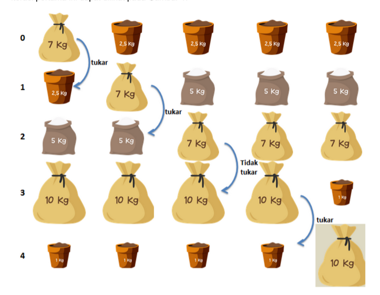

**Gambar 1. Iterasi Pertama Bubble Sort**

Iterasi Kedua, bertujuan untuk memindahkan data terbesar kedua, yaitu 7, agar menempati posisi tepat sebelum data 10, seperti yang terlihat pada Gambar 2.

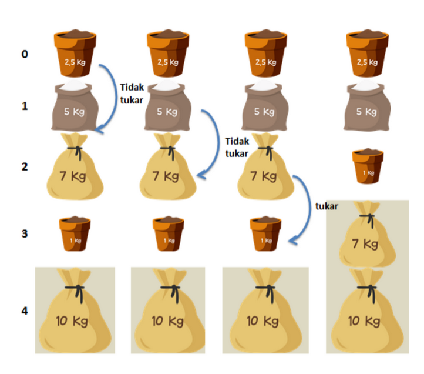

**Gambar 2. Iterasi Kedua Bubble Sort** Iterasi Ketiga, bertujuan untuk memindahkan data terbesar ketiga, yaitu 5, untuk menempati posisi tepat sebelum data 7, seperti yang ditunjukkan pada Gambar 3.

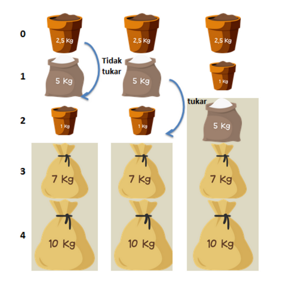

**Gambar 3. Iterasi Ketiga Bubble Sort**

Proses ini dilakukan terus menerus sampai tidak ada data lagi yang akan dibandingkan. Data dalam keadaan terurut, dapat dilihat pada Gambar 4.

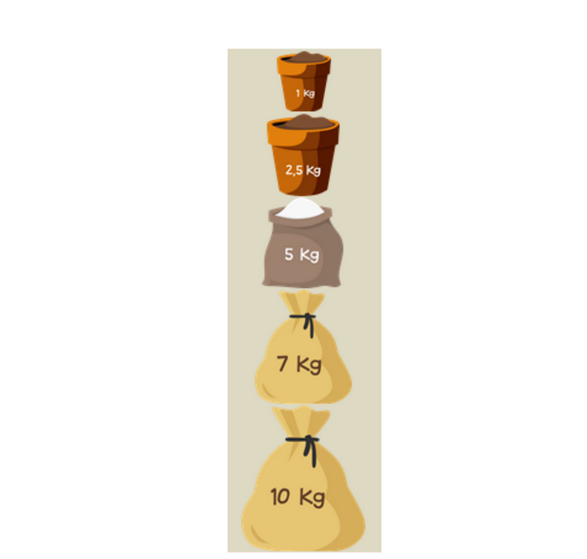

**Gambar 4. Iterasi Terakhir Bubble Sort**

# **CODE**

```python
def bubbleSort(listData):
    print('Data yang akan diurutkan : ', listData)
    count=0
    for outIter in range(len(listData)-1,-1,-1):
        print('outIter=',outIter)
        # count=count+1
        print ('Iterasi ke-', count,':')
        for i in range(outIter):
            if listData[i]>listData[i+1]:
                # temp=listData[i]
                # listData[i]=listData[i+1]
                # listData[i+1]=temp
                listData[i],listData[i+1]=listData[i+1],listData[i]
                count+=1
            print(outIter,'=',listData)
        # print("Jumlah Swap =",count)
    print('Data urut-',listData)
    # print("Total Swap =",count)
```

```python
a=[12,0,5,1,11,20,4,2]
bubbleSort(a)
# b=[12,11,5,1,0]
# print('--')
# bubbleSort(b)
```

```
Data yang akan diurutkan :  [12, 0, 5, 1, 11, 20, 4, 2]
outIter= 7
Iterasi ke- 0 :
7 = [0, 12, 5, 1, 11, 20, 4, 2]
7 = [0, 5, 12, 1, 11, 20, 4, 2]
7 = [0, 5, 1, 12, 11, 20, 4, 2]
7 = [0, 5, 1, 11, 12, 20, 4, 2]
7 = [0, 5, 1, 11, 12, 20, 4, 2]
7 = [0, 5, 1, 11, 12, 4, 20, 2]
7 = [0, 5, 1, 11, 12, 4, 2, 20]
outIter= 6
Iterasi ke- 6 :
6 = [0, 5, 1, 11, 12, 4, 2, 20]
6 = [0, 1, 5, 11, 12, 4, 2, 20]
6 = [0, 1, 5, 11, 12, 4, 2, 20]
6 = [0, 1, 5, 11, 12, 4, 2, 20]
6 = [0, 1, 5, 11, 4, 12, 2, 20]
6 = [0, 1, 5, 11, 4, 2, 12, 20]
outIter= 5
Iterasi ke- 9 :
5 = [0, 1, 5, 11, 4, 2, 12, 20]
5 = [0, 1, 5, 11, 4, 2, 12, 20]
5 = [0, 1, 5, 11, 4, 2, 12, 20]
5 = [0, 1, 5, 4, 11, 2, 12, 20]
5 = [0, 1, 5, 4, 2, 11, 12, 20]
outIter= 4
Iterasi ke- 11 :
4 = [0, 1, 5, 4, 2, 11, 12, 20]
4 = [0, 1, 5, 4, 2, 11, 12, 20]
4 = [0, 1, 4, 5, 2, 11, 12, 20]
4 = [0, 1, 4, 2, 5, 11, 12, 20]
outIter= 3
Iterasi ke- 13 :
3 = [0, 1, 4, 2, 5, 11, 12, 20]
3 = [0, 1, 4, 2, 5, 11, 12, 20]
3 = [0, 1, 2, 4, 5, 11, 12, 20]
outIter= 2
Iterasi ke- 14 :
2 = [0, 1, 2, 4, 5, 11, 12, 20]
2 = [0, 1, 2, 4, 5, 11, 12, 20]
outIter= 1
Iterasi ke- 14 :
1 = [0, 1, 2, 4, 5, 11, 12, 20]
outIter= 0
Iterasi ke- 14 :
Data urut- [0, 1, 2, 4, 5, 11, 12, 20]
```

```python
b=[11,12,1,5,0]
bubbleSort(b)
```

```
Data yang akan diurutkan :  [11, 12, 1, 5, 0]
outIter= 4
Iterasi ke- 0 :
4 = [11, 12, 1, 5, 0]
4 = [11, 1, 12, 5, 0]
4 = [11, 1, 5, 12, 0]
4 = [11, 1, 5, 0, 12]
outIter= 3
Iterasi ke- 3 :
3 = [1, 11, 5, 0, 12]
3 = [1, 5, 11, 0, 12]
3 = [1, 5, 0, 11, 12]
outIter= 2
Iterasi ke- 6 :
2 = [1, 5, 0, 11, 12]
2 = [1, 0, 5, 11, 12]
outIter= 1
Iterasi ke- 7 :
1 = [0, 1, 5, 11, 12]
outIter= 0
Iterasi ke- 8 :
Data urut- [0, 1, 5, 11, 12]
```